# Hundred Shades of Linear Regression

### Yet Another Post on Regression?

**Short answer**: No.  
**Long answer**: An year or so ago I took [Andrew Ng's](https://www.coursera.org/instructor/andrewng) brilliant [Machine Learning](https://www.coursera.org/learn/machine-learning) course. I learned about regression, classification, neural networks, support vector machines, principal components and collaborative filtering. I gained quite a bit of understanding of core topics of ML by painstakingly working through every assignment. The course gave me a kickstart in the domain but I decided to deep dive further. So I enrolled in an intermediate [Deep Learning program](https://classroom.udacity.com/nanodegrees/nd101/syllabus/core-curriculum) offered by Udacity and completed it recently. The course was packed with more advanced ML algorithms and correspondingly complex models. So just like many ML engineers now I carry a portfolio consisting of neural, convolutional, recurrent and generative adversarial networks.

Some time has passed and I haven't used some of the techniques outside the class. So now I want to test my understanding of the guts of these algorithms. In the case of ML one of the most interesting algorithm is linear regression, which is kind of a starting point for more esoteric algorithms.

I'm rolling out this [blog](https://safwanahmad.github.io/) that is my take on machine learning. This first post titled Hundred shades of Linear Regression will look at this simple algorithm from many different perspectives. Hope it will help you and me understand the nuts & bolts of linear regression.

### What is linear regression?

Linear regression got its name for [historical reasons](https://stats.stackexchange.com/a/11089/164767). In simple language it means line fitting. But a line is a two dimensional thing, in practice linear regression covers multidimensional data too, when we actually fit a plane not a line to some data.

Most typical introductions to linear regression use matrix algebra. In this post, however, I will use simple algebra and calculus to derive all equations. Interestingly, Python has a very powerful symbolic math library called [SymPy](http://www.sympy.org/en/index.html) that will let us do all calculation like we do them with pen and paper.

The data we will use here comes from CMU's [Body Fat dataset](http://lib.stat.cmu.edu/datasets/bodyfat). This data is stored in a csv file. And in order to visualize data I need to access it inside the notebook. For this purpose I am using [pandas](https://pandas.pydata.org/) library.

```python
import pandas as pn
```

In the next cell I'm going to read csv data into a nice readable structure and try to print few entries from top and see what the different columns are.

```python
# Read data and print some rows
dataframe = pn.read_csv('bodyfat.csv', sep="\s+")
dataframe.head()
```

|  | Under Water Density | Percent body fat (Siri) | Age (years) | Weight (lbs) | Height (inches) | Neck circumference (cm) | Chest circumference (cm) | Abdomen 2 circumference (cm) | Hip circumference (cm) | Thigh circumference (cm) | Knee circumference (cm) | Ankle circumference (cm) | Biceps (extended) circumference (cm) | Forearm circumference (cm) | Wrist circumference (cm) |
| --- | --- | --- | --- | --- | --- | --- | --- | --- | --- | --- | --- | --- | --- | --- | --- |
| 0 | 1.0708 | 12.3 | 23 | 154.25 | 67.75 | 36.2 | 93.1 | 85.2 | 94.5 | 59.0 | 37.3 | 21.9 | 32.0 | 27.4 | 17.1 |
| 1 | 1.0853 | 6.1 | 22 | 173.25 | 72.25 | 38.5 | 93.6 | 83.0 | 98.7 | 58.7 | 37.3 | 23.4 | 30.5 | 28.9 | 18.2 |
| 2 | 1.0414 | 25.3 | 22 | 154.00 | 66.25 | 34.0 | 95.8 | 87.9 | 99.2 | 59.6 | 38.9 | 24.0 | 28.8 | 25.2 | 16.6 |
| 3 | 1.0751 | 10.4 | 26 | 184.75 | 72.25 | 37.4 | 101.8 | 86.4 | 101.2 | 60.1 | 37.3 | 22.8 | 32.4 | 29.4 | 18.2 |
| 4 | 1.0340 | 28.7 | 24 | 184.25 | 71.25 | 34.4 | 97.3 | 100.0 | 101.9 | 63.2 | 42.2 | 24.0 | 32.2 | 27.7 | 17.7 |

```python
from pandas.tools.plotting import scatter_matrix
from numpy.random import randn

df = pn.DataFrame(dataframe, columns=list(dataframe.columns.values)[3:8])
```

```python
import matplotlib.pyplot as py
%matplotlib inline
```

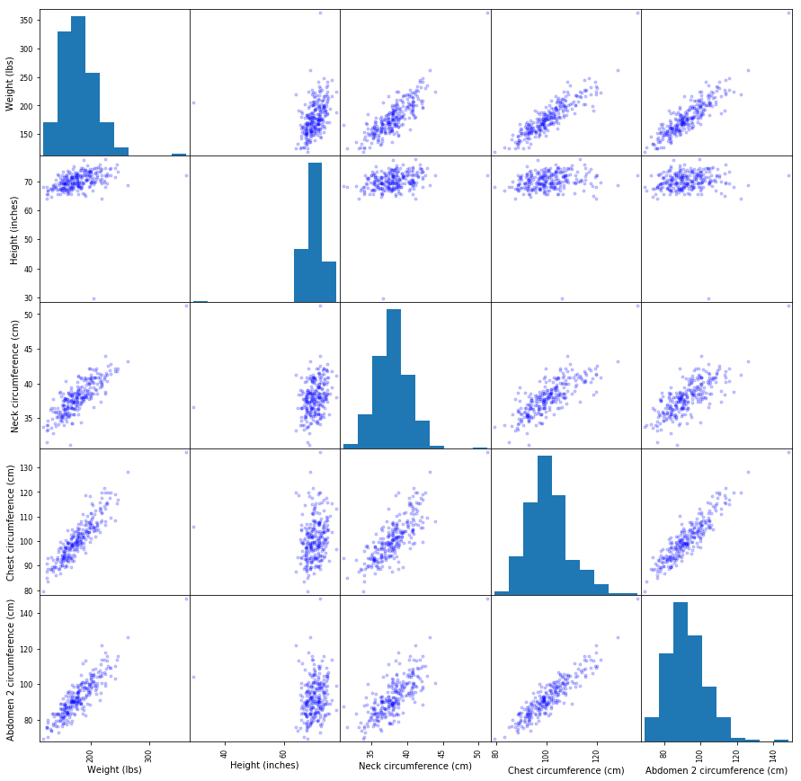

```python
scatter_matrix(df, alpha=0.2, figsize=(15, 15), diagonal='hist', c='blue')
py.show()
```

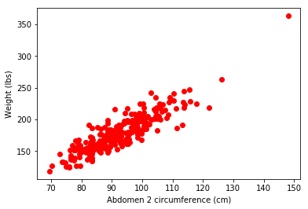

```python
requiredData = dataframe[['Weight (lbs)','Abdomen 2 circumference (cm)']]
py.plot(requiredData.iloc[:,1], requiredData.iloc[:,0], 'or')
py.xlabel('Abdomen 2 circumference (cm)')
py.ylabel('Weight (lbs)')
py.show()
```

```
(151, 2)
(101, 2)
```

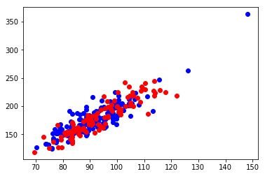

```python
# Split data between train and test set
nTrain = int(0.6 * requiredData.shape[0])

train = requiredData.iloc[0:nTrain]
test = requiredData.iloc[nTrain :]
print(train.shape)
print(test.shape)
py.plot(train.iloc[:,1], train.iloc[:,0], 'ob')
py.plot(test.iloc[:,1], test.iloc[:,0], 'or')
py.show()
```

```python
import sympy as sp

# Build a model with just one input variable and one output variable
y,x,m,c = sp.symbols('y x m c')

y = m * x + c

# Define the cost function. We use MSE.

cost, y_actual = sp.symbols('cost y_actual')

cost = (y - y_actual)**2
```

```python
# Find out the total cost for input data (train)
total_cost = 0
#print(cost)
for i in range(train.shape[0]):
    y_pred = y.subs(x, train.iloc[i,1])
    #print(y_pred)
    #print(cost.subs([(y, y_pred), (y_actual, train.iloc[i,0])]))
    total_cost += cost.subs([(y, y_pred), (y_actual, train.iloc[i,0])])
sp.pretty_print(total_cost)
```

```
                    2                       2                        2
(c + 70.4⋅m - 127.5)  + (c + 73.7⋅m - 133.5)  + (c + 73.9⋅m - 133.25)  + (c +

               2                        2                       2
74.6⋅m - 131.5)  + (c + 76.0⋅m - 125.25)  + (c + 76.0⋅m - 125.0)  + (c + 76.3⋅

           2                        2                        2
m - 151.25)  + (c + 76.4⋅m - 140.25)  + (c + 76.5⋅m - 143.75)  + (c + 77.1⋅m -

        2                        2                        2
 159.75)  + (c + 77.6⋅m - 152.25)  + (c + 77.6⋅m - 136.25)  + (c + 77.9⋅m - 13

     2                        2                        2
9.25)  + (c + 78.0⋅m - 152.25)  + (c + 78.4⋅m - 155.25)  + (c + 78.8⋅m - 162.5

 2                       2                       2                        2
)  + (c + 79.1⋅m - 168.0)  + (c + 79.5⋅m - 148.5)  + (c + 79.6⋅m - 152.75)  +

                     2                        2                        2
(c + 79.7⋅m - 159.25)  + (c + 80.0⋅m - 148.75)  + (c + 81.5⋅m - 164.25)  + (c

                  2                       2                        2
+ 81.8⋅m - 148.25)  + (c + 81.9⋅m - 156.0)  + (c + 82.0⋅m - 137.25)  + (c + 82

             2                        2                        2
.5⋅m - 191.0)  + (c + 82.8⋅m - 146.75)  + (c + 82.9⋅m - 160.75)  + (c + 83.0⋅m

          2                        2                        2
 - 173.25)  + (c + 83.1⋅m - 165.25)  + (c + 83.3⋅m - 160.25)  + (c + 83.3⋅m -

      2                        2                        2
143.0)  + (c + 83.4⋅m - 135.75)  + (c + 83.5⋅m - 160.75)  + (c + 83.6⋅m - 186.

   2                       2                       2                        2
25)  + (c + 83.9⋅m - 151.5)  + (c + 84.1⋅m - 161.0)  + (c + 84.5⋅m - 160.25)

                       2                        2                        2
+ (c + 84.6⋅m - 156.75)  + (c + 85.2⋅m - 154.25)  + (c + 85.3⋅m - 188.15)  + (

                    2                        2                       2
```

[output cut: 88 more lines]

```

                       2                        2                        2
 (c + 104.2⋅m - 201.25)  + (c + 104.3⋅m - 212.0)  + (c + 104.3⋅m - 205.0)  + (

                    2                         2                        2
c + 104.8⋅m - 216.0)  + (c + 105.0⋅m - 183.25)  + (c + 105.3⋅m - 202.5)  + (c

                  2                         2                        2
+ 105.5⋅m - 205.5)  + (c + 106.6⋅m - 212.75)  + (c + 106.8⋅m - 223.0)  + (c +

                2                        2                         2
108.1⋅m - 203.0)  + (c + 111.2⋅m - 217.0)  + (c + 113.1⋅m - 191.75)  + (c + 11

               2                         2                         2
5.6⋅m - 247.25)  + (c + 126.2⋅m - 262.75)  + (c + 148.1⋅m - 363.15)
```

```python
# Simplify the total cost
total_cost = sp.simplify(total_cost)
sp.pretty_print(total_cost)
```

```
       2                                         2
151.0⋅c  + 27663.6⋅c⋅m - 53538.6⋅c + 1283386.38⋅m  - 4982416.37⋅m + 4867297.84


5
```

```python
# Find differentiation w.r.t m and c
grad_m = sp.diff(total_cost, m)
grad_c = sp.diff(total_cost, c)
sp.pretty_print(grad_m)
sp.pretty_print(grad_c)

# Solve the two equations
solution = sp.solvers.solve([grad_m, grad_c])
print(solution)
```

```
27663.6⋅c + 2566772.76⋅m - 4982416.37
302.0⋅c + 27663.6⋅m - 53538.6
{c: -41.4689755547256, m: 2.38805616830518}
```

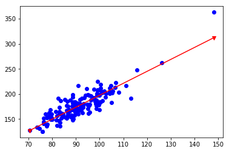

```python
# Plot the line corresponding to best solution
py.plot(train.iloc[:,1], train.iloc[:,0], 'ob')
x_min = train.iloc[:,1].min()
x_max = train.iloc[:,1].max()
y_min = solution[m]*x_min + solution[c]
y_max = solution[m]*x_max + solution[c]
py.plot([x_min, x_max], [y_min, y_max], 'r-v')
```

```python
import numpy as np
min_slope = np.tan(0)
max_slope = np.tan(1.4)

min_intercept = -100
max_intercept = 100

slope_sample = np.linspace(min_slope, max_slope, num=25)
intercept_sample= np.linspace(min_intercept, max_intercept, num = 50)

x_grid, y_grid = np.meshgrid(slope_sample, intercept_sample)

#print(x_grid[0])
#print(x_grid[1])

value_grid_points = np.zeros_like(x_grid)

for i in range(len(x_grid)):
    for j in range(len(x_grid[0])):
        #print(total_cost.subs([(m, x_grid[i,j]), (c, y_grid[i,j])]))
        value_grid_points[i,j] = total_cost.subs([(m, x_grid[i,j]), (c, y_grid[i,j])])
```

```python
sphere_x_position = float(solution[m])
sphere_y_position = float(solution[c])
sphere_z_position = float(total_cost.subs([(m,solution[m]), (c, solution[c])]))

# Take out the coefficients
coefficients_dict = total_cost.as_coefficients_dict()

c_square = float( coefficients_dict[c**2] )
m_square = float( coefficients_dict[m**2] )
c_term   = float( coefficients_dict[c] )
m_term   = float( coefficients_dict[m] )
c_m_term = float( coefficients_dict[c*m])
constant = float( coefficients_dict[1] )

print(c_square, m_square, c_term, m_term, c_m_term, constant)
```

```
151.0 1283386.3800000004 -53538.600000000006 -4982416.370000001 27663.600000000006 4867297.845000001
```

```python
import plotly as py
import plotly.graph_objs as go

py.offline.init_notebook_mode()

z_data = value_grid_points

theta = np.linspace(0,2*np.pi,20)
phi = np.linspace(0,np.pi,20)
x_sphere = np.outer(0.125*np.cos(theta),np.sin(phi))
y_sphere = np.outer(2*np.sin(theta),np.sin(phi))
z_sphere = np.outer(100000*np.ones(20),np.cos(phi))  # note this is 2d now

data = [
    go.Surface(x=x_grid, y=y_grid,
        z=z_data,
        colorscale='Viridis'
    ),
    go.Surface(
        x=sphere_x_position +x_sphere,
        y=sphere_y_position+y_sphere,
        z=sphere_z_position+z_sphere,
        showscale=False
    )
]

cost_layout = go.Layout(
    title='Cost Function',
    autosize=True,
    width=400,
    height=400,
    margin=dict(
        l=10,
        r=10,
        b=10,
        t=90
    ),
    scene=dict(
        camera=dict(
            up=dict(x=0, y=0, z=1),
            center=dict(x=0, y=0, z=0),
            eye=dict(x=0.0, y=1.25, z=1.0)
        )
    )
)
```

```python
#print(y_sphere)
```

```python
from bokeh.plotting import figure, output_notebook, show, reset_output
from bokeh.models import CustomJS, ColumnDataSource, Slider, WidgetBox
from bokeh.layouts import layout
import math

reset_output()
output_notebook()

fig = figure(plot_width=300, plot_height=300)
fig.triangle(train.iloc[:,1], train.iloc[:,0], color="green")

# Convert numpy data type to python native type
xs_endpoints = [float(x_min), float(x_max)]
ys_endpoints = [float(y_min), float(y_max)]

input_data = ColumnDataSource(data=dict(x=xs_endpoints, y=ys_endpoints))

# Coefficients needed to compute the total cost
cost_coefficients = ColumnDataSource(data=dict(
    coeffs=[c_square, m_square, c_term, m_term, c_m_term, constant]))

# Sphere surface coordinates
sphere_coordinates = ColumnDataSource(data=dict(
    sphere=[x_sphere, y_sphere, z_sphere]))


line = fig.line('x','y',source=input_data, line_width=2)

file = open("callback.js","r")
js = file.read()

# Java Script code for callback
javascript = ColumnDataSource(data=dict(js=[js]))

callback_update_m_c_plot = CustomJS(args=dict(source1=input_data, source2= cost_coefficients,
                                             source3 = sphere_coordinates, javascript=javascript),
                                    code=javascript.data['js'][0])


slider_slope = Slider(start=0, end=1.4, value=math.atan(solution[m]), step=(0.01), title="Slope")
slider_slope.js_on_change('value', callback_update_m_c_plot)
#slider_slope.js_on_change('value', callback_update_cost_plot)

slider_intercept = Slider(start=-100, end=100, value=(int)(solution[c]), step=10, title="Intercept")
slider_intercept.js_on_change('value', callback_update_m_c_plot)
#slider_intercept.js_on_change('value', callback_update_cost_plot)

cost_fig = go.Figure(data=data, layout=cost_layout)
py.offline.iplot(cost_fig, filename='elevations-3d-surface')

widgets = WidgetBox(slider_slope, slider_intercept)

layout = layout([widgets, fig])
show(layout)
```

[interactive chart not shown]